# A4 - Feed Forward Neural Network

## Adib Rezaei - 810198401

# Dataloader

```python
from sklearn.utils import shuffle

class Dataloader:
    '''
    This class prepares the dataset for the neural network.
    '''

    def __init__(self, data, labels, n_classes, batch_size=None, shuffle=False):
        '''
        This is the constructor. It gets dataset information and initializes the
        Dataloader class fields.
            Parameters:
                data: features your dataset in pandas.Dataframe format.
                labels: labels of your dataset in pandas.Dataframe format.
                n_classes: number of classes you have in your dataset.
                batch_size: the number of samples that will be propagated through the network.
                shuffle: boolean value indicating whether or not the dataset should be shuffled
        '''

        assert len(data)==len(labels)
        self.__n_classes = n_classes
        self.__batch_size = batch_size
        self.__shuffle = shuffle
        self.__data = data
        self.__onehot_labels = self.__onehot(labels, self.__n_classes)

    def __onehot(self, labels, n_classes):
        '''
        This private method gets labels and provides one_hot vectors of labels.
        For categorical variables where no such ordinal relationship exists,
        the integer encoding is not enough.
        In this case, a one-hot encoding can be applied to the integer representation.
        This is where the integer encoded variable is removed, and a new binary variable is
        added for each unique integer value.
        example:
            red,    green,    blue
            1,      0,        0
            0,      1,        0
            0,      0,        1
                Parameters:
                        label: lables of your dataset in pandas.Dataframe format.
                        n_classes: number of classes you have in your dataset.

                Returns:
                    onehot_vectors: onehot vectors of the labels
        '''
        # TODO: Implement
        onehot_vectors = []
        for label in labels:
            onehot_vector = [0] * n_classes
            if label == 'cat':
                onehot_vector[0] = 1
            else :
                onehot_vector[1] = 1
            onehot_vectors.append(onehot_vector)
        return onehot_vectors

    def __shuffle_dataset(self):
        '''
        This private method shuffles your dataset.
        It uses data and onehot_labels to shuffle them
        symmetrical.
        '''
        # TODO: Implement
        self.__data = shuffle(self.__data, random_state=42)


    def __iter__(self):
        '''
        The __iter__() function returns an iterator for the
        given object (array, set, tuple, etc., or custom objects).
        This will return your dataset in the batch_size given. This should
        be used to provide data for the neural network.
        '''

        if self.__shuffle:
            self.__shuffle_dataset()

        if self.__batch_size==None:
            yield (np.matrix(self.__data), np.matrix(self.__onehot_labels))
            return

        for idx in range(0, len(self.__data), self.__batch_size):
            yield (np.matrix(self.__data[idx:idx+self.__batch_size]),
                   np.matrix(self.__onehot_labels[idx:idx+self.__batch_size]))
```

# Activation Functions

```python
class Identical:
    '''
    This is the Identical activation function. This activation function just
    return the value it gets.
    '''

    def __init__(self):
        '''
        This is the constructor. It does not have any fields
        as a result, there is no need to do anything in the constructor.
        '''
        pass

    def __val(self, matrix):
        '''
        This private method gets a matrix and uses the activity function on that.
        As this is an identical activity function, it just
        returns np.matrix of the input.

            Parameters:
                matrix: np.matrix of values
            Returns:
                identical_value: np.matrix of input with float datatypes
        '''
        identical_value = np.matrix(matrix, dtype=float)
        return identical_value

    def derivative(self, matrix):
        '''
        This method returns the derivation of the input.
        As the derivation of x is one, this method returns
        a matrix of one with the shape of the input matrix.

            Parameters:
                matrix: np.matrix of values
            Returns:
                identical_derivative: np.matrix of ones with matrix shape
        '''
        temp = np.matrix(matrix, dtype=float)
        identical_derivative = np.matrix(np.full(np.shape(temp), 1.))
        return identical_derivative

    def __call__(self, matrix):
        '''
        __call__ is a special function in Python that, when implemented inside a class,
        gives its instances (objects) the ability to behave like a function.
        Here we return the _value method output.

            Parameters:
                matrix: np.matrix of values
            Returns:
                __val(matrix): __val return value for the input matrix
        '''
        return self.__val(matrix)


class Relu:
    '''
    This is the Relu activation function.
    The rectified linear activation function or ReLU for short
    is a piecewise linear function that will output the input directly
    if it is positive, otherwise, it will output zero.
    '''

    def __init__(self):
        '''
        This is the constructor. It does not have any fields
        as a result, there is no need to do anything in the constructor.
        '''
        pass

    def __val(self, matrix):
        '''
        This private method gets a matrix and uses the activity function on that.
        It will set 0 in the matrix if the value is less than 0 else, it returns the value itself.

            Parameters:
                matrix: np.matrix of values
            Returns:
                relu_value: np.matrix of relu activation function result
        '''
        # TODO: Implement
        relu_value = np.array([np.array(x, copy=True) for x in matrix])
        relu_value[relu_value < 0] = 0
        return relu_value

    def derivative(self, matrix):
        '''
        Returns the derivation value of relu function on input matrix.

            Parameters:
                matrix: np.matrix of values
            Returns:
                relu_derivative: np.matrix of relu activation function derivation result
        '''
        # TODO: Implement
        relu_derivative = np.array([np.array(x, copy=True) for x in matrix])
        relu_derivative[relu_derivative < 0] = 0
        relu_derivative[relu_derivative > 0] = 1
        return relu_derivative

    def __call__(self, matrix):
        '''
        __call__ is a special function in Python that, when implemented inside a class,
        gives its instances (objects) the ability to behave like a function.
        Here we return the _relu method output.

            Parameters:
                matrix: np.matrix of values
            Returns:
                __relu(matrix): __relu return value for the input matrix
        '''
        return self.__val(matrix)


class LeakyRelu:
    '''
    This is the Leaky Relu activation function.
    Leaky Rectified Linear Unit, or Leaky ReLU,
    is a type of activation function based on a ReLU,
    but it has a small slope for negative values instead
    of a flat slope.
    '''

    def __init__(self, negative_slope=0.01):
        '''
        This is the constructor.
        It sets negative_slope field.
            Parameters:
                negative_slope: slope for negative input values
        '''
        self.negative_slope = 0.01

    def __val(self, matrix):
        '''
        This private method gets a matrix and uses the activity function on that.
        It will set negative_slope*value in the matrix if the value is less than 0, else it
        returns the value itself.

            Parameters:
                matrix: np.matrix of values
            Returns:
                relu_value: np.matrix of relu activation function result
        '''
        # TODO: Implement
        leacky_relu_value = np.array([np.array(x, copy=True) for x in matrix])
        leacky_relu_value = np.where(leacky_relu_value > 0, leacky_relu_value, leacky_relu_value * 0.01)
        return leacky_relu_value

    def derivative(self, matrix):
        '''
        Returns the derivation value of leaky relu function on input matrix.

            Parameters:
                matrix: np.matrix of values
            Returns:
                leacky_relu_derivative: np.matrix of leaky relu activation function derivation result
        '''
        # TODO: Implement
        leacky_relu_derivative = np.array([np.array(x, copy=True) for x in matrix])
        leacky_relu_derivative = np.where(leacky_relu_derivative > 0, 1, 0.01)
        return leacky_relu_derivative

    def __call__(self, matrix):
        '''
        __call__ is a special function in Python that, when implemented inside a class,
        gives its instances (objects) the ability to behave like a function.
        Here we return the _val method output.

            Parameters:
                matrix: np.matrix of values
            Returns:
                __val(matrix): __val return value for the input matrix
        '''
        return self.__val(matrix)


class Sigmoid:
    '''
    A sigmoid function is a mathematical function having a
    characteristic "S"-shaped curve or sigmoid curve.
    It return S(x)=1/(1+e^-x)
    '''

    def __init__(self): pass

    def __val(self, matrix):
        '''
        Returns 1/(1+e^-x) of values

            Parameters:
                matrix: np.matrix of values
            Returns:
                sigmoid_value: np.matrix of relu activation function result
        '''
        # TODO: Implement
        sigmoid_value = 1.0 / (1.0 + np.exp(-matrix))
        return sigmoid_value

    def derivative(self, matrix):
        '''
        Returns the derivation value of sigmoid function on input matrix.

            Parameters:
                matrix: np.matrix of values
            Returns:
                sigmoid_derivative: np.matrix of sigmoid activation function derivation result
        '''
        # TODO: Implement
        sigmoid_value = self.__val(matrix)
        sigmoid_derivative = np.multiply(sigmoid_value, 1 - sigmoid_value)
        return sigmoid_derivative

    def __call__(self, matrix):
        '''
        __call__ is a special function in Python that, when implemented inside a class,
        gives its instances (objects) the ability to behave like a function.
        Here we return the _val method output.

            Parameters:
                matrix: np.matrix of values
            Returns:
                __val(matrix): __val return value for the input matrix
        '''
        return self.__val(matrix)


class Softmax:
    '''
    The softmax function, also known as softargmax  or normalized
    exponential function is a generalization of the logistic
    function to multiple dimensions. It is used in multinomial logistic
    regression and is often used as the last activation function of a neural
    network to normalize the output of a network to a probability distribution
    over predicted output classes, based on Luce's choice axiom.
    Softmax return (e^x_i / (Σe^x_j for j = 1, ..., J))
    '''

    def __init__(self):
        '''
        This is the constructor. It does not have any fields
        as a result, there is no need to do anything in the constructor.
        '''
        pass

    def __val(self, matrix):
        '''
        This private method gets a matrix and uses the softmax on that.
        Softmax return (e^x_i / (Σe^x_j for j = 1, ..., J))

            Parameters:
                matrix: np.matrix of values
            Returns:
                relu_value: np.matrix of relu activation function result
        '''
        # TODO: Implement
        softmax_value = np.zeros(matrix.shape)
        for i in range(len(matrix)):
            tmp = np.exp(matrix[i] - np.max(matrix[i]))
            softmax_value[i] = tmp / np.sum(tmp)
        return softmax_value

    def __call__(self, matrix):
        '''
        __call__ is a special function in Python that, when implemented inside a class,
        gives its instances (objects) the ability to behave like a function.
        Here we return the _val method output.

            Parameters:
                matrix: np.matrix of values
            Returns:
                __val(matrix): __val return value for the input matrix
        '''
        return self.__val(matrix)



class Tanh:

    def __init__(self):
      '''
      This is the constructor. It does not have any fields
      as a result, there is no need to do anything in the constructor.
      '''
      pass

    def __val(self, matrix):
        '''
        This private method gets a matrix and uses the activity function on that.
        It performs Tanh on the values.

            Parameters:
                matrix: np.matrix of values
            Returns:
                tanh_value: np.matrix of Tanh activation function result
        '''
        # TODO: Implement
        tanh_value = np.tanh(matrix)
        return tanh_value

    def derivative(self, matrix):
        '''
        Returns the derivation value of Tanh function on input matrix.

            Parameters:
                matrix: np.matrix of values
            Returns:
                sigmoid_derivative: np.matrix of Tanh activation function derivation result
        '''
        # TODO: Implement
        tanh_derivative = 1 - np.multiply(matrix, matrix)
        return tanh_derivative

    def __call__(self, matrix):
        '''
        __call__ is a special function in Python that, when implemented inside a class,
        gives its instances (objects) the ability to behave like a function.
        Here we return the _val method output.

            Parameters:
                matrix: np.matrix of values
            Returns:
                __val(matrix): __val return value for the input matrix
        '''
        return self.__val(matrix)
```


# Loss Function

```python
class CrossEntropy: #(with softmax)
    '''
    Cross-entropy is a measure of the difference between two probability
    distributions for a given random variable or set of events. You might
    recall that information quantifies the number of bits required to encode
    and transmit an event.
    The above image can help you.
    '''

    EPS = 1e-50

    def __init__(self):
        '''
        This is the constructor. It does not have any fields
        as a result, there is no need to do anything in the constructor.
        '''
        pass

    def __val(self, true_val, expected_val):
        '''
        L(y^, y) = - Σ (y^(k)log (y^)^(k)) for k in K
        Parameters:
            true_val: calculated values (generated by neural network)
            expected_val: real values in dataset
        Returns:
            cross_entropy_value: cross entropy of inputs
        '''
        assert np.shape(true_val)==np.shape(expected_val)
        # TODO: Implement
        softmax = Softmax()
        cross_entropy_value = np.multiply(-expected_val, np.log(np.clip(softmax(true_val), self.EPS, 1 - self.EPS))).sum(axis = 1)
        return cross_entropy_value

    def derivative(self, true_val, expected_val):
        '''
        Returns derivation of cross entropy.
            Parameters:
                true_val: calculated values (generated by neural network)
                expected_val: real values in dataset
            Returns:
                cross_entropy_derivative: cross entropy derivation of inputs
        '''
        assert np.shape(true_val)==np.shape(expected_val)
        # TODO: Implement
        softmax = Softmax()
        return softmax(true_val + self.EPS) - expected_val

    def __call__(self, true_val, expected_val):
        '''
        __call__ is a special function in Python that, when implemented inside a class,
        gives its instances (objects) the ability to behave like a function.
        Here we return the _val method output.

            Parameters:
                true_val: calculated values (generated by neural network)
                expected_val: real values in dataset
            Returns:
                __val(matrix): __val return value for the input matrix
        '''
        return self.__val(true_val, expected_val)
```

# Layer

```python
import math

class Layer:
    '''
    The layer class is used to define neural network layers.
    It stores all needed information for each layer, such as neurons count,
    weight matrix, bias, the output after applying the activation function, etc.
    '''

    DEFAULT_LOW, DEFAULT_HIGH, DEFAULT_MEAN, DEFAULT_VAR = 0, 0.05, 0., 1.

    def __init__(self, input_size, output_size, activation=Identical(), initial_weight='uniform',
                 **initializing_parameters):
        '''
        Parameters:
            input_size: the size of the input of this layer.
            output_size: the size of the output after this layer.
            activation: the activation function. It can be initialized to either of the previously defined activation classes.
                               default is an Identical activation function.
            initial_weight: either normal or uniform. It defines the method for weight initialization.
        '''

        assert type(initial_weight)==str, 'Undefined activation function!'

        self.__weight_initializer_dict = {'uniform':self.__uniform_weight, 'normal':self.__normal_weight}

        assert initial_weight in self.__weight_initializer_dict, 'Undefined weight initialization function!'


        self.__n_neurons = output_size
        weight_initializer = self.__weight_initializer_dict[initial_weight]
        self.__weight = weight_initializer(input_size, self.__n_neurons, **initializing_parameters)
        self.__bias = weight_initializer(1, self.__n_neurons, **initializing_parameters)
        self.__activation = activation

        self.__last_input = None
        self.__last_activation_input = None
        self.__last_activation_output = None
        self.__last_activation_derivative = None

    def forward(self, layer_input):
        '''
        It calculates the output of this layer for the layer_input argument.
        This method also stores __last_input, __last_activation_input, and __last_activation_derivative
        for future use in backpropagation.
        Parameters:
            layer_input: 2d np.matrix representing the input matrix of this layer.
        Returns:
            Final output of this layer after applying the activation function.
        '''
        assert np.ndim(layer_input)==2
        assert np.size(self.__weight,0) == np.size(layer_input,1)
        # TODO: Implement
        self.__last_input = layer_input
        self.__last_activation_input =  layer_input @ self.weight + self.bias
        self.__last_activation_output = self.activation(self.__last_activation_input)
        self.__last_activation_derivative = np.squeeze(self.activation.derivative(self.__last_activation_input))
        return self.__last_activation_output

    def update_weights(self, backprop_tensor, lr):
        '''
        It updates Layer weights according to the backpropagation matrix and learning rate.
        This method updates bias values as well.
        Parameters:
            backprop_tensor: 2d np.matrix passed from the next layer containing gradient values.
            lr: learning rate
        Returns:
            backprop_tensor to be used by the previous layer.
        '''
        assert np.ndim(backprop_tensor)==2
        assert np.size(backprop_tensor,0) == np.size(self.__last_activation_derivative,0)
        assert np.size(backprop_tensor,1) == self.__n_neurons
        # TODO: Implement
        xt = self.__last_input.transpose()
        yp = np.multiply(backprop_tensor, self.__last_activation_derivative)
        bt = np.matrix(np.tile(1, (1, yp.shape[0])))
        wp = np.matmul(xt, yp)
        bp = np.matmul(bt, yp)
        backprop_tensor = np.matmul(yp, self.__weight.transpose())
        self.__weight -= wp * lr
        self.__bias -= bp * lr
        return backprop_tensor

    def __uniform_weight(self, dim1, dim2, **initializing_parameters):
        '''
        Initializes weights as a uniform distribution between low and high values.
        It uses default low and high values unless low or high are passed in initializing_parameters.
        Parameters:
            dim1: the size of the first dimension of weights.
            dim2: the size of the second dimension of weights.
            initializing_parameters: other initializing parameters; it can include custom low or high values.
        Returns:
            np.matrix with size (dim1, dim2) initialized using uniformly distributed values.
        '''
        low, high = self.DEFAULT_LOW, self.DEFAULT_HIGH
        if 'low' in initializing_parameters.keys(): low = initializing_parameters['low']
        if 'high' in initializing_parameters.keys(): high = initializing_parameters['high']
        # TODO: Implement
        weights = np.random.uniform(low = low, high = high, size = (dim1, dim2))
        return weights

    def __normal_weight(self, dim1, dim2, **initializing_parameters):
        '''
        Initializes weights as a normal distribution with mean and var values.
        It uses default mean and variance values unless mean or var are passed in initializing_parameters.
        Parameters:
            dim1: the size of the first dimension of weights.
            dim2: the size of the second dimension of weights.
            initializing_parameters: other initializing parameters; it can include custom mean or var values.
        Returns:
            np.matrix with size (dim1, dim2) initialized using normaly distributed values.
        '''
        mean, var = self.DEFAULT_MEAN, self.DEFAULT_VAR
        if 'mean' in initializing_parameters.keys(): mean = initializing_parameters['mean']
        if 'var' in initializing_parameters.keys(): var = initializing_parameters['var']
        # TODO: Implement
        weights = np.random.normal(loc = mean, scale = math.sqrt(var), size=(dim1, dim2))
        return weights

    @property
    def n_neurons(self): return self.__n_neurons

    @property
    def weight(self): return self.__weight

    @property
    def bias(self): return self.__bias

    @property
    def activation(self): return self.__activation
```

# Feed Forward Neural Network

```python
from copy import deepcopy

class FeedForwardNN:
    '''
    This class is used in order to implement custom feed-forward neural networks.
    The FeedForwardNN class stores a list of layers that determines all network layers.
    It also consists of the learning rate and loss function.
    '''
    def __init__(self, input_shape):
        '''
        Parameters:
            input_shape: the size of the first input to our neural network.
        '''

        self.__input_shape = input_shape
        self.__output_shape = None

        self.__layers_list = []

        self.__lr = None
        self.__loss = None


    def add_layer(self, n_neurons, activation=Relu(), initial_weight='uniform', **initializing_parameters):
        '''
         This method adds a new custom layer to the layers_list.
         Parameters:
             n_neurons: number of neurons in this layer
             activation: the activation function of this layer, default is Relu
             initial_weight: either a uniform or normal, default is uniform
             initializing_parameters: other initializing parameters such as low, high, mean, var, etc
        '''

        assert type(n_neurons)==int, "Invalid number of neurons for the layer!"
        assert n_neurons>0, "Invalid number of neurons for the layer!"

        n_prev_neurons = self.__input_shape if len(self.__layers_list)==0 else self.__layers_list[-1].n_neurons
        new_layer = Layer(n_prev_neurons, n_neurons, activation, initial_weight, **initializing_parameters)
        self.__layers_list.append(new_layer)
        self.__output_shape = self.__layers_list[-1].n_neurons


    def set_training_param(self, loss=CrossEntropy(), lr=1e-3):
        '''
        This method is used to set training parameters.
        Parameters:
            loss: loss function, default is CrossEntropy
            lr: learning rate, default is 1e-3
        '''
        assert self.__layers_list, "Uncomplete model!"
        self.__loss = loss
        self.__lr = lr


    def forward(self, network_input):
        '''
        This method calculates the output of the complete neural network for a passed input.
        Parameters:
            network_input: input of the neural network
        Returns:
            network_output: output of the neural network after forwarding the network_input
        '''
        assert type(self.__output_shape) != None, "Model is not compiled!"
        # TODO: Implement
        network_output = deepcopy(network_input)
        for layer in self.__layers_list:
            network_output = layer.forward(network_output)
            network_output = np.squeeze(network_output)
        return network_output


    def fit(self, epochs, trainloader, testloader=None, print_results=True):
        '''
        This method trains the neural network using specified parameters.
        It runs the __train private method epoch times and fills the log dictionary.
        Parameters:
            epochs: number of epochs to run
            trainloader: DataLoader for train data
            testloader: DataLoader for test data
            print_results: whether or not to print the results
        Returns:
            log: complete log of the training process as a dictionary consisting of
            train_accuracy, train_loss, test_accuracy, test_loss
        '''

        assert type(self.__output_shape) != None, "Model is not compiled!"
        assert type(self.__lr) != None and type(self.__loss) != None, "Training paramenters are not set!"

        log = {"train_accuracy":[], "train_loss":[], "test_accuracy":[], "test_loss":[]}

        for epoch in range(1, epochs+1):

            if print_results:
                print('Epoch {}:'.format(epoch))

            average_accuracy, average_loss = self.__train(trainloader)
            log['train_accuracy'].append(average_accuracy)
            log['train_loss'].append(average_loss)
            if print_results:
                print('\tTrain: Average Accuracy: {}\tAverage Loss: {}'.format(average_accuracy, average_loss))

            if type(testloader) != type(None):
                average_accuracy, average_loss = self.__test(testloader)
                log['test_accuracy'].append(average_accuracy)
                log['test_loss'].append(average_loss)
                if print_results:
                    print('\tTest: Average Accuracy: {}\tAverage Loss: {}'.format(average_accuracy, average_loss))

        return log


    def __train(self, trainloader):
        '''
        Trains the neural network for one epoch.
        Parameters:
            trainloader: A DataLoader consisting of train data
        Returns:
            batch_accuracy, batch_loss: mean of all batch_accuracies, batch_losses
        '''
        bach_accuracies, batch_losses = [], []
        for x_train, y_train in trainloader:
            batch_accuracy, batch_loss = self.__train_on_batch(x_train, y_train)
            bach_accuracies.append(batch_accuracy)
            batch_losses.append(batch_loss)
        return np.mean(bach_accuracies), np.mean(batch_losses)


    def __test(self, testloader):
        '''
        Test the neural network using a testloader.
        Parameters:
            testloader: A DataLoader of test data
        Returns:
            batch_accuracy, batch_loss: mean of all batch_accuracies, batch_losses
        '''
        bach_accuracies, batch_losses = [], []
        for x_test, y_test in testloader:
            batch_accuracy, batch_loss = self.__test_on_batch(x_test, y_test)
            bach_accuracies.append(batch_accuracy)
            batch_losses.append(batch_loss)
        return np.mean(bach_accuracies), np.mean(batch_losses)


    def __train_on_batch(self, x_batch, y_batch):
        '''
        Trains the neural network for one batch of train data.
        Parameters:
            x_batch: one batch data
            y_batch: labels for one batch
        Returns:
            (batch_accuracy, batch_average_loss)
        '''
        # TODO: Implement
        output_batch = self.forward(x_batch)
        batch_accuracy = self.__compute_accuracy(output_batch, y_batch)
        batch_average_loss = self.__update_weights(output_batch, y_batch)
        return (batch_accuracy, batch_average_loss)


    def __test_on_batch(self, x_batch, y_batch):
        '''
        Tests the neural network for one batch of test data.
        Parameters:
            x_batch: one batch data
            y_batch: labels for one batch
        Returns:
            (batch_accuracy, batch_average_loss)
        '''
        # TODO: Implement
        output_batch = self.forward(x_batch)
        cross_entropy = CrossEntropy()
        batch_average_loss = np.sum(cross_entropy(output_batch, y_batch)) / len(output_batch)
        batch_accuracy = self.__compute_accuracy(output_batch, y_batch)
        return (batch_accuracy, batch_average_loss)


    def __get_labels(self, outputs):
        '''
        Parameters:
            outputs: output of the neural network
        Returns:
            labels: labels generated from the outputs of the neural network
        '''
        # TODO: Implement
        labels = np.argmax(outputs, axis = 1)
        return labels


    def __compute_accuracy(self, output, expected_output):
        '''
        Computes accuracy by comparing output and expected_output.
        Parameters:
            output: actual output of the neural network
            expected_output: expected output
        Returns:
            accuracy
        '''
        # TODO: Implement
        labels = self.__get_labels(output)
        correct = 0
        for i in range(len(output)):
            if (expected_output[i, labels[i]] == 1):
                correct += 1

        accuracy = correct / len(output)
        return accuracy


    def __update_weights(self, output, y_train):
        '''
        Updates weights of all layers according to neural network output and labels.
        Parameters:
            output: output of the neural network
            y_train: y labels for one batch of train data
        Returns:
            None
        '''
        # TODO: Implement
        crossEntropy = CrossEntropy()
        derivative = crossEntropy.derivative(output, y_train)
        for layer in reversed(self.__layers_list):
             derivative = layer.update_weights(derivative, self.__lr)
        return np.sum(crossEntropy(output, y_train)) / len(output)
```

# Part 1 - PreProcessing

```python
import numpy as np
import pandas as pd
import matplotlib.pyplot as plt
```

```python
df = pd.read_csv('labels.csv')
df
```

|  | id | label |
| --- | --- | --- |
| 0 | 8 | horse |
| 1 | 10 | cat |
| 2 | 12 | horse |
| 3 | 13 | horse |
| 4 | 18 | cat |
| ... | ... | ... |
| 9995 | 49979 | horse |
| 9996 | 49980 | cat |
| 9997 | 49983 | cat |
| 9998 | 49984 | cat |
| 9999 | 49987 | horse |

10000 rows × 2 columns

Split data into test and train using train test split of sklearn

```python
from sklearn.model_selection import train_test_split
X_train, X_test, y_train, y_test = train_test_split(df['id'], df['label'], test_size=0.20)
```

### Q1)

Reading an image using PIL and printing out the value of a random pixel

```python
from PIL import Image

image_id = df['id'].values[0]
im = Image.open('data/' + str(image_id) + '.png')
l = [list(pixel) for pixel in im.getdata()]
print(l[:1])
```

```
[[28, 35, 39]]
```

### Q2)

showing a random image from train data

```
horse
```

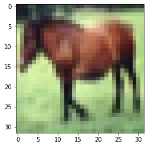

```python
import matplotlib.image as mpimg

print(df['label'].values[0])
image_id = df['id'].values[0]
image = mpimg.imread('data/' + str(image_id) + '.png')
fig = plt.figure()
plt.imshow(image)
plt.show()
```

```
cat
```

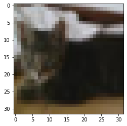

```python
print(df['label'].values[1])
image_id = df['id'].values[1]
image = mpimg.imread('data/' + str(image_id) + '.png')
fig = plt.figure()
plt.imshow(image)
plt.show()
```

### Q4)

reading images and turn them into gray scale in order to reduce the features

```python
import matplotlib.image as mpimg


images = []
for image_id in df['id'].values:
    # Converts to black and white scale
    image = Image.open('data/' + str(image_id) + '.png').convert('L')
    images.append(list(image.getdata()))
    image.close()
```

each pixel range is now between 0 and 255

```python
# from itertools import chain
# flatImages = [list(chain.from_iterable(img)) for img in images]
images_df = pd.DataFrame(images)
images_df
```

|  | 0 | 1 | 2 | 3 | 4 | 5 | 6 | 7 | 8 | 9 | ... | 1014 | 1015 | 1016 | 1017 | 1018 | 1019 | 1020 | 1021 | 1022 | 1023 |
| --- | --- | --- | --- | --- | --- | --- | --- | --- | --- | --- | --- | --- | --- | --- | --- | --- | --- | --- | --- | --- | --- |
| 0 | 33 | 34 | 41 | 75 | 76 | 43 | 42 | 56 | 70 | 77 | ... | 120 | 113 | 137 | 141 | 131 | 150 | 153 | 128 | 126 | 123 |
| 1 | 124 | 103 | 93 | 99 | 101 | 136 | 171 | 170 | 143 | 93 | ... | 107 | 108 | 110 | 112 | 114 | 116 | 118 | 121 | 120 | 121 |
| 2 | 147 | 171 | 169 | 173 | 201 | 212 | 196 | 135 | 119 | 133 | ... | 155 | 152 | 125 | 76 | 70 | 123 | 134 | 132 | 133 | 135 |
| 3 | 203 | 200 | 200 | 201 | 201 | 201 | 202 | 202 | 202 | 202 | ... | 153 | 148 | 145 | 146 | 146 | 145 | 139 | 139 | 140 | 138 |
| 4 | 105 | 135 | 145 | 130 | 82 | 55 | 48 | 52 | 52 | 53 | ... | 70 | 70 | 65 | 62 | 64 | 58 | 55 | 48 | 48 | 50 |
| ... | ... | ... | ... | ... | ... | ... | ... | ... | ... | ... | ... | ... | ... | ... | ... | ... | ... | ... | ... | ... | ... |
| 9995 | 162 | 83 | 104 | 107 | 104 | 104 | 108 | 119 | 126 | 130 | ... | 239 | 239 | 239 | 239 | 239 | 239 | 239 | 236 | 227 | 254 |
| 9996 | 4 | 4 | 5 | 0 | 65 | 174 | 167 | 154 | 153 | 150 | ... | 52 | 65 | 85 | 75 | 49 | 23 | 7 | 12 | 11 | 3 |
| 9997 | 41 | 39 | 39 | 40 | 42 | 42 | 44 | 46 | 47 | 48 | ... | 59 | 59 | 59 | 61 | 61 | 62 | 63 | 62 | 62 | 65 |
| 9998 | 32 | 32 | 30 | 31 | 33 | 37 | 38 | 41 | 88 | 147 | ... | 184 | 122 | 147 | 178 | 218 | 224 | 216 | 225 | 233 | 218 |
| 9999 | 141 | 141 | 142 | 142 | 143 | 143 | 144 | 144 | 144 | 144 | ... | 194 | 192 | 186 | 188 | 184 | 185 | 183 | 190 | 182 | 181 |

10000 rows × 1024 columns

We scale the numbers to 0-1 using min max scaler

if we don't do scaling the weights we further calculate couldn't affect good enough on features

```python
from sklearn.preprocessing import MinMaxScaler
scaler = MinMaxScaler()
scaler.fit(images)
scaled_images = scaler.transform(images)
```

```python
images_df = pd.DataFrame(scaled_images)
images_df
```

|  | 0 | 1 | 2 | 3 | 4 | 5 | 6 | 7 | 8 | 9 | ... | 1014 | 1015 | 1016 | 1017 | 1018 | 1019 | 1020 | 1021 | 1022 | 1023 |
| --- | --- | --- | --- | --- | --- | --- | --- | --- | --- | --- | --- | --- | --- | --- | --- | --- | --- | --- | --- | --- | --- |
| 0 | 0.129412 | 0.133333 | 0.160784 | 0.294118 | 0.298039 | 0.168627 | 0.164706 | 0.219608 | 0.274510 | 0.301961 | ... | 0.470588 | 0.443137 | 0.537255 | 0.552941 | 0.513725 | 0.588235 | 0.600000 | 0.501961 | 0.494118 | 0.482353 |
| 1 | 0.486275 | 0.403922 | 0.364706 | 0.388235 | 0.396078 | 0.533333 | 0.670588 | 0.666667 | 0.560784 | 0.364706 | ... | 0.419608 | 0.423529 | 0.431373 | 0.439216 | 0.447059 | 0.454902 | 0.462745 | 0.474510 | 0.470588 | 0.474510 |
| 2 | 0.576471 | 0.670588 | 0.662745 | 0.678431 | 0.788235 | 0.831373 | 0.768627 | 0.529412 | 0.466667 | 0.521569 | ... | 0.607843 | 0.596078 | 0.490196 | 0.298039 | 0.274510 | 0.482353 | 0.525490 | 0.517647 | 0.521569 | 0.529412 |
| 3 | 0.796078 | 0.784314 | 0.784314 | 0.788235 | 0.788235 | 0.788235 | 0.792157 | 0.792157 | 0.792157 | 0.792157 | ... | 0.600000 | 0.580392 | 0.568627 | 0.572549 | 0.572549 | 0.568627 | 0.545098 | 0.545098 | 0.549020 | 0.541176 |
| 4 | 0.411765 | 0.529412 | 0.568627 | 0.509804 | 0.321569 | 0.215686 | 0.188235 | 0.203922 | 0.203922 | 0.207843 | ... | 0.274510 | 0.274510 | 0.254902 | 0.243137 | 0.250980 | 0.227451 | 0.215686 | 0.188235 | 0.188235 | 0.196078 |
| ... | ... | ... | ... | ... | ... | ... | ... | ... | ... | ... | ... | ... | ... | ... | ... | ... | ... | ... | ... | ... | ... |
| 9995 | 0.635294 | 0.325490 | 0.407843 | 0.419608 | 0.407843 | 0.407843 | 0.423529 | 0.466667 | 0.494118 | 0.509804 | ... | 0.937255 | 0.937255 | 0.937255 | 0.937255 | 0.937255 | 0.937255 | 0.937255 | 0.925490 | 0.890196 | 0.996078 |
| 9996 | 0.015686 | 0.015686 | 0.019608 | 0.000000 | 0.254902 | 0.682353 | 0.654902 | 0.603922 | 0.600000 | 0.588235 | ... | 0.203922 | 0.254902 | 0.333333 | 0.294118 | 0.192157 | 0.090196 | 0.027451 | 0.047059 | 0.043137 | 0.011765 |
| 9997 | 0.160784 | 0.152941 | 0.152941 | 0.156863 | 0.164706 | 0.164706 | 0.172549 | 0.180392 | 0.184314 | 0.188235 | ... | 0.231373 | 0.231373 | 0.231373 | 0.239216 | 0.239216 | 0.243137 | 0.247059 | 0.243137 | 0.243137 | 0.254902 |
| 9998 | 0.125490 | 0.125490 | 0.117647 | 0.121569 | 0.129412 | 0.145098 | 0.149020 | 0.160784 | 0.345098 | 0.576471 | ... | 0.721569 | 0.478431 | 0.576471 | 0.698039 | 0.854902 | 0.878431 | 0.847059 | 0.882353 | 0.913725 | 0.854902 |
| 9999 | 0.552941 | 0.552941 | 0.556863 | 0.556863 | 0.560784 | 0.560784 | 0.564706 | 0.564706 | 0.564706 | 0.564706 | ... | 0.760784 | 0.752941 | 0.729412 | 0.737255 | 0.721569 | 0.725490 | 0.717647 | 0.745098 | 0.713725 | 0.709804 |

10000 rows × 1024 columns

### Q3)

Plot the number of images in test and train dataset

```python
image_train, image_test, label_train, label_test = train_test_split(images_df.iloc[:, :], df['label'], test_size=0.20)
```

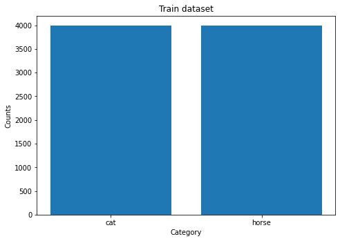

```python
index, counts = np.unique(label_train.values, return_counts = True)
fig = plt.figure()
ax = fig.add_axes([0 ,0, 1, 1])
ax.bar(index ,counts)

plt.xlabel("Category")
plt.ylabel("Counts")
plt.title("Train dataset")
plt.show()
```

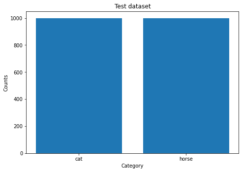

```python
index, counts = np.unique(label_test.values, return_counts = True)
fig = plt.figure()
ax = fig.add_axes([0 ,0, 1, 1])
ax.bar(index ,counts)

plt.xlabel("Category")
plt.ylabel("Counts")
plt.title("Test dataset")
plt.show()
```

## Part 3 - Classify using FFNN

```python
INPUT_SHAPE = 1024
LEARNING_RATE = 0.001
EPOCHS = 15
BATCH_SIZE = 32
TRAINLOADER = Dataloader(data = image_train.values.tolist(), labels = label_train.values.tolist(), n_classes = 2, batch_size = BATCH_SIZE, shuffle = False)
TESTLOADER = Dataloader(data = image_test.values.tolist(), labels = label_test.values.tolist(), n_classes = 2, batch_size = BATCH_SIZE, shuffle = False)


network = FeedForwardNN(INPUT_SHAPE)
network.add_layer(n_neurons = 32, activation = Relu(), weight_initializer='uniform')
network.add_layer(n_neurons = 32, activation = Relu(), weight_initializer='uniform')
network.add_layer(n_neurons = 2, activation = Identical(), weight_initializer='uniform')
network.set_training_param(loss=CrossEntropy(), lr=LEARNING_RATE)
log = network.fit(EPOCHS, TRAINLOADER, TESTLOADER)
```

```
Epoch 1:
	Train: Average Accuracy: 0.4925	Average Loss: 0.8653059179634333
	Test: Average Accuracy: 0.5	Average Loss: 0.6931607661534298
Epoch 2:
	Train: Average Accuracy: 0.4985	Average Loss: 0.6933320731517795
	Test: Average Accuracy: 0.5	Average Loss: 0.693162114974043
Epoch 3:
	Train: Average Accuracy: 0.4985	Average Loss: 0.6933320370304121
	Test: Average Accuracy: 0.5	Average Loss: 0.6931621394844175
Epoch 4:
	Train: Average Accuracy: 0.4985	Average Loss: 0.6933320364620701
	Test: Average Accuracy: 0.5	Average Loss: 0.6931621399195224
Epoch 5:
	Train: Average Accuracy: 0.4985	Average Loss: 0.6933320364520078
	Test: Average Accuracy: 0.5	Average Loss: 0.6931621399272432
Epoch 6:
	Train: Average Accuracy: 0.4985	Average Loss: 0.6933320364518295
	Test: Average Accuracy: 0.5	Average Loss: 0.6931621399273804
Epoch 7:
	Train: Average Accuracy: 0.4985	Average Loss: 0.6933320364518262
	Test: Average Accuracy: 0.5	Average Loss: 0.6931621399273825
Epoch 8:
	Train: Average Accuracy: 0.4985	Average Loss: 0.6933320364518261
	Test: Average Accuracy: 0.5	Average Loss: 0.6931621399273825
Epoch 9:
	Train: Average Accuracy: 0.4985	Average Loss: 0.6933320364518261
	Test: Average Accuracy: 0.5	Average Loss: 0.6931621399273827
Epoch 10:
	Train: Average Accuracy: 0.4985	Average Loss: 0.6933320364518261
	Test: Average Accuracy: 0.5	Average Loss: 0.6931621399273827
Epoch 11:
	Train: Average Accuracy: 0.4985	Average Loss: 0.6933320364518261
	Test: Average Accuracy: 0.5	Average Loss: 0.6931621399273827
Epoch 12:
	Train: Average Accuracy: 0.4985	Average Loss: 0.6933320364518261
	Test: Average Accuracy: 0.5	Average Loss: 0.6931621399273827
Epoch 13:
	Train: Average Accuracy: 0.4985	Average Loss: 0.6933320364518261
	Test: Average Accuracy: 0.5	Average Loss: 0.6931621399273827
Epoch 14:
	Train: Average Accuracy: 0.4985	Average Loss: 0.6933320364518261
	Test: Average Accuracy: 0.5	Average Loss: 0.6931621399273827
Epoch 15:
	Train: Average Accuracy: 0.4985	Average Loss: 0.6933320364518261
	Test: Average Accuracy: 0.5	Average Loss: 0.6931621399273827
```

### Weight Impact

the derivative would remain the same if all weights were initialized to zero. so neurons will learn same features in each iteration and doesn't get any better. also any constant initialization will produce a poor result. we should produce a uniform or normal weight initialization to get better results.

### Learning Rate Impact

High learning Impact : 0.01

```python
LEARNING_RATE = 0.01

network.set_training_param(loss=CrossEntropy(), lr=LEARNING_RATE)
log = network.fit(EPOCHS, TRAINLOADER, TESTLOADER)
```

```
Epoch 1:
	Train: Average Accuracy: 0.50125	Average Loss: 0.6944828747002685
	Test: Average Accuracy: 0.5	Average Loss: 0.6934480926481321
Epoch 2:
	Train: Average Accuracy: 0.5015	Average Loss: 0.6943723870147142
	Test: Average Accuracy: 0.5	Average Loss: 0.6934480926481321
Epoch 3:
	Train: Average Accuracy: 0.5015	Average Loss: 0.6943723870147142
	Test: Average Accuracy: 0.5	Average Loss: 0.6934480926481321
Epoch 4:
	Train: Average Accuracy: 0.5015	Average Loss: 0.6943723870147142
	Test: Average Accuracy: 0.5	Average Loss: 0.6934480926481321
Epoch 5:
	Train: Average Accuracy: 0.5015	Average Loss: 0.6943723870147142
	Test: Average Accuracy: 0.5	Average Loss: 0.6934480926481321
Epoch 6:
	Train: Average Accuracy: 0.5015	Average Loss: 0.6943723870147142
	Test: Average Accuracy: 0.5	Average Loss: 0.6934480926481321
Epoch 7:
	Train: Average Accuracy: 0.5015	Average Loss: 0.6943723870147142
	Test: Average Accuracy: 0.5	Average Loss: 0.6934480926481321
Epoch 8:
	Train: Average Accuracy: 0.5015	Average Loss: 0.6943723870147142
	Test: Average Accuracy: 0.5	Average Loss: 0.6934480926481321
Epoch 9:
	Train: Average Accuracy: 0.5015	Average Loss: 0.6943723870147142
	Test: Average Accuracy: 0.5	Average Loss: 0.6934480926481321
Epoch 10:
	Train: Average Accuracy: 0.5015	Average Loss: 0.6943723870147142
	Test: Average Accuracy: 0.5	Average Loss: 0.6934480926481321
Epoch 11:
	Train: Average Accuracy: 0.5015	Average Loss: 0.6943723870147142
	Test: Average Accuracy: 0.5	Average Loss: 0.6934480926481321
Epoch 12:
	Train: Average Accuracy: 0.5015	Average Loss: 0.6943723870147142
	Test: Average Accuracy: 0.5	Average Loss: 0.6934480926481321
Epoch 13:
	Train: Average Accuracy: 0.5015	Average Loss: 0.6943723870147142
	Test: Average Accuracy: 0.5	Average Loss: 0.6934480926481321
Epoch 14:
	Train: Average Accuracy: 0.5015	Average Loss: 0.6943723870147142
	Test: Average Accuracy: 0.5	Average Loss: 0.6934480926481321
Epoch 15:
	Train: Average Accuracy: 0.5015	Average Loss: 0.6943723870147142
	Test: Average Accuracy: 0.5	Average Loss: 0.6934480926481321
```

### Learning Rate Impact

```python
LEARNING_RATE = 0.0001

network.set_training_param(loss=CrossEntropy(), lr=LEARNING_RATE)
log = network.fit(EPOCHS, TRAINLOADER, TESTLOADER)
```

```
Epoch 1:
	Train: Average Accuracy: 0.49575	Average Loss: 0.6936483183539562
	Test: Average Accuracy: 0.5163690476190477	Average Loss: 0.6927280392302707
Epoch 2:
	Train: Average Accuracy: 0.49575	Average Loss: 0.6933648642483493
	Test: Average Accuracy: 0.5163690476190477	Average Loss: 0.6928950638595578
Epoch 3:
	Train: Average Accuracy: 0.49575	Average Loss: 0.6932375609953305
	Test: Average Accuracy: 0.5163690476190477	Average Loss: 0.6930478209640994
Epoch 4:
	Train: Average Accuracy: 0.497	Average Loss: 0.6931803956097067
	Test: Average Accuracy: 0.4836309523809524	Average Loss: 0.6931685209937994
Epoch 5:
	Train: Average Accuracy: 0.50225	Average Loss: 0.6931547268955642
	Test: Average Accuracy: 0.4836309523809524	Average Loss: 0.6932576366347094
Epoch 6:
	Train: Average Accuracy: 0.50425	Average Loss: 0.693143201248621
	Test: Average Accuracy: 0.4836309523809524	Average Loss: 0.6933210511004018
Epoch 7:
	Train: Average Accuracy: 0.50425	Average Loss: 0.6931380261659501
	Test: Average Accuracy: 0.4836309523809524	Average Loss: 0.6933652061609116
Epoch 8:
	Train: Average Accuracy: 0.50425	Average Loss: 0.6931357026038076
	Test: Average Accuracy: 0.4836309523809524	Average Loss: 0.6933955406904568
Epoch 9:
	Train: Average Accuracy: 0.50425	Average Loss: 0.6931346594077249
	Test: Average Accuracy: 0.4836309523809524	Average Loss: 0.6934162031997031
Epoch 10:
	Train: Average Accuracy: 0.50425	Average Loss: 0.6931341910940994
	Test: Average Accuracy: 0.4836309523809524	Average Loss: 0.6934301999055696
Epoch 11:
	Train: Average Accuracy: 0.50425	Average Loss: 0.6931339808885036
	Test: Average Accuracy: 0.4836309523809524	Average Loss: 0.693439646914215
Epoch 12:
	Train: Average Accuracy: 0.50425	Average Loss: 0.6931338865573218
	Test: Average Accuracy: 0.4836309523809524	Average Loss: 0.6934460078869069
Epoch 13:
	Train: Average Accuracy: 0.50425	Average Loss: 0.6931338442397446
	Test: Average Accuracy: 0.4836309523809524	Average Loss: 0.6934502841384269
Epoch 14:
	Train: Average Accuracy: 0.50425	Average Loss: 0.6931338252653542
	Test: Average Accuracy: 0.4836309523809524	Average Loss: 0.6934531558708127
Epoch 15:
	Train: Average Accuracy: 0.50425	Average Loss: 0.6931338167640186
	Test: Average Accuracy: 0.4836309523809524	Average Loss: 0.693455083033948
```

### Sigmoid Activation Function

when the input grows the sigmoid function will have samller gradient and slower learning rate. on the other hand derivate of a sigmoid function is always less than one and in deep neural network when multiplying gradiants it results in zero or close to zero very quick.

```python
LEARNING_RATE = 0.001

network = FeedForwardNN(INPUT_SHAPE)
network.add_layer(n_neurons = 32, activation = Sigmoid(), weight_initializer='uniform')
network.add_layer(n_neurons = 32, activation = Sigmoid(), weight_initializer='uniform')
network.add_layer(n_neurons = 2, activation = Identical(), weight_initializer='uniform')
network.set_training_param(loss=CrossEntropy(), lr=LEARNING_RATE)
log = network.fit(EPOCHS, TRAINLOADER, TESTLOADER)
```

```
Epoch 1:
	Train: Average Accuracy: 0.50025	Average Loss: 0.695687160612413
	Test: Average Accuracy: 0.5163690476190477	Average Loss: 0.6928861414545158
Epoch 2:
	Train: Average Accuracy: 0.50025	Average Loss: 0.6956679738837779
	Test: Average Accuracy: 0.5163690476190477	Average Loss: 0.6928780776009706
Epoch 3:
	Train: Average Accuracy: 0.50025	Average Loss: 0.6956492333587511
	Test: Average Accuracy: 0.5163690476190477	Average Loss: 0.692870092090419
Epoch 4:
	Train: Average Accuracy: 0.501	Average Loss: 0.6956305354328917
	Test: Average Accuracy: 0.5163690476190477	Average Loss: 0.692862187794551
Epoch 5:
	Train: Average Accuracy: 0.501	Average Loss: 0.6956118828633812
	Test: Average Accuracy: 0.5163690476190477	Average Loss: 0.6928543675684151
Epoch 6:
	Train: Average Accuracy: 0.501	Average Loss: 0.6955932783898147
	Test: Average Accuracy: 0.5163690476190477	Average Loss: 0.6928466342469147
Epoch 7:
	Train: Average Accuracy: 0.501	Average Loss: 0.6955747247320535
	Test: Average Accuracy: 0.5163690476190477	Average Loss: 0.6928389906412588
Epoch 8:
	Train: Average Accuracy: 0.50175	Average Loss: 0.6955562245880981
	Test: Average Accuracy: 0.5163690476190477	Average Loss: 0.6928314395353705
Epoch 9:
	Train: Average Accuracy: 0.50175	Average Loss: 0.6955377806319811
	Test: Average Accuracy: 0.5163690476190477	Average Loss: 0.6928239836822649
Epoch 10:
	Train: Average Accuracy: 0.50175	Average Loss: 0.6955193955116861
	Test: Average Accuracy: 0.5163690476190477	Average Loss: 0.6928166258004012
Epoch 11:
	Train: Average Accuracy: 0.50175	Average Loss: 0.6955010718470932
	Test: Average Accuracy: 0.5163690476190477	Average Loss: 0.6928093685700151
Epoch 12:
	Train: Average Accuracy: 0.50175	Average Loss: 0.6954828122279606
	Test: Average Accuracy: 0.5163690476190477	Average Loss: 0.6928022146294455
Epoch 13:
	Train: Average Accuracy: 0.502	Average Loss: 0.6954646192119384
	Test: Average Accuracy: 0.5163690476190477	Average Loss: 0.692795166571458
Epoch 14:
	Train: Average Accuracy: 0.502	Average Loss: 0.6954464953226239
	Test: Average Accuracy: 0.5163690476190477	Average Loss: 0.692788226939576
Epoch 15:
	Train: Average Accuracy: 0.502	Average Loss: 0.6954284430476592
	Test: Average Accuracy: 0.5163690476190477	Average Loss: 0.6927813982244289
```

### Hyperbolic Tangent Activation Function

it is more computation expensive than sigmoid and has disadvantages of gradient vanishing

### Leaky Relu Activation Function

Leaky ReLU has two benefits:

- It fixes the “dying ReLU” problem, as it doesn’t have zero-slope parts.
- It speeds up training. There is evidence that having the “mean activation” be close to 0 makes training faster. (It helps keep off-diagonal entries of the Fisher information matrix small, but you can safely ignore this.) Unlike ReLU, leaky ReLU is more “balanced,” and may therefore learn faster.

https://medium.com/@danqing/a-practical-guide-to-relu-b83ca804f1f7#:~:text=Leaky%20ReLU%20has%20two%20benefits,to%200%20makes%20training%20faster.

```python
LEARNING_RATE = 0.001

network = FeedForwardNN(INPUT_SHAPE)
network.add_layer(n_neurons = 32, activation = LeakyRelu(), weight_initializer='uniform')
network.add_layer(n_neurons = 32, activation = LeakyRelu(), weight_initializer='uniform')
network.add_layer(n_neurons = 2, activation = Identical(), weight_initializer='uniform')
network.set_training_param(loss=CrossEntropy(), lr=LEARNING_RATE)
log = network.fit(EPOCHS, TRAINLOADER, TESTLOADER)
```

```
Epoch 1:
	Train: Average Accuracy: 0.54425	Average Loss: 0.8910403378564495
	Test: Average Accuracy: 0.5357142857142857	Average Loss: 0.6918937766784122
Epoch 2:
	Train: Average Accuracy: 0.55175	Average Loss: 0.6908277786450481
	Test: Average Accuracy: 0.5367063492063492	Average Loss: 0.6918306641319804
Epoch 3:
	Train: Average Accuracy: 0.552625	Average Loss: 0.6907897505502814
	Test: Average Accuracy: 0.5372023809523809	Average Loss: 0.6918023959215727
Epoch 4:
	Train: Average Accuracy: 0.5525	Average Loss: 0.6907517351387864
	Test: Average Accuracy: 0.5376984126984127	Average Loss: 0.6917736391197257
Epoch 5:
	Train: Average Accuracy: 0.552125	Average Loss: 0.6907135975622598
	Test: Average Accuracy: 0.5381944444444444	Average Loss: 0.6917443014009925
Epoch 6:
	Train: Average Accuracy: 0.5525	Average Loss: 0.690675307900832
	Test: Average Accuracy: 0.5386904761904762	Average Loss: 0.6917143786906305
Epoch 7:
	Train: Average Accuracy: 0.55275	Average Loss: 0.6906368397409901
	Test: Average Accuracy: 0.5386904761904762	Average Loss: 0.6916838691201277
Epoch 8:
	Train: Average Accuracy: 0.552625	Average Loss: 0.6905981696647031
	Test: Average Accuracy: 0.5386904761904762	Average Loss: 0.6916527724773684
Epoch 9:
	Train: Average Accuracy: 0.55275	Average Loss: 0.6905592769243415
	Test: Average Accuracy: 0.5381944444444444	Average Loss: 0.6916210898994555
Epoch 10:
	Train: Average Accuracy: 0.553125	Average Loss: 0.690520143143518
	Test: Average Accuracy: 0.5381944444444444	Average Loss: 0.6915888236009179
Epoch 11:
	Train: Average Accuracy: 0.554	Average Loss: 0.690480752043304
	Test: Average Accuracy: 0.5386904761904762	Average Loss: 0.6915559766347532
Epoch 12:
	Train: Average Accuracy: 0.554125	Average Loss: 0.6904410891931572
	Test: Average Accuracy: 0.5391865079365079	Average Loss: 0.691522552683963
Epoch 13:
	Train: Average Accuracy: 0.554875	Average Loss: 0.6904011417855366
	Test: Average Accuracy: 0.5386904761904762	Average Loss: 0.6914885558811253
Epoch 14:
	Train: Average Accuracy: 0.555	Average Loss: 0.6903608984329108
	Test: Average Accuracy: 0.5386904761904762	Average Loss: 0.6914539906534739
Epoch 15:
	Train: Average Accuracy: 0.55575	Average Loss: 0.6903203489857135
	Test: Average Accuracy: 0.5386904761904762	Average Loss: 0.691418861590995
```

### Batch Size Impact

Two batch sizes are tested

- 16
- 256

```python
BATCH_SIZE = 16
TRAINLOADER = Dataloader(data = image_train.values.tolist(), labels = label_train.values.tolist(), n_classes = 2, batch_size = BATCH_SIZE, shuffle = False)
TESTLOADER = Dataloader(data = image_test.values.tolist(), labels = label_test.values.tolist(), n_classes = 2, batch_size = BATCH_SIZE, shuffle = False)

network = FeedForwardNN(INPUT_SHAPE)
network.add_layer(n_neurons = 32, activation = Relu(), weight_initializer='uniform')
network.add_layer(n_neurons = 32, activation = Relu(), weight_initializer='uniform')
network.add_layer(n_neurons = 2, activation = Identical(), weight_initializer='uniform')
network.set_training_param(loss=CrossEntropy(), lr=LEARNING_RATE)
log = network.fit(EPOCHS, TRAINLOADER, TESTLOADER)
```

```
Epoch 1:
	Train: Average Accuracy: 0.49975	Average Loss: 0.741537059995916
	Test: Average Accuracy: 0.517	Average Loss: 0.6929831287230075
Epoch 2:
	Train: Average Accuracy: 0.495	Average Loss: 0.693331243878939
	Test: Average Accuracy: 0.483	Average Loss: 0.6932009037860667
Epoch 3:
	Train: Average Accuracy: 0.4925	Average Loss: 0.6933178057269568
	Test: Average Accuracy: 0.483	Average Loss: 0.6932515670285948
Epoch 4:
	Train: Average Accuracy: 0.492375	Average Loss: 0.6933163920562068
	Test: Average Accuracy: 0.483	Average Loss: 0.6932435480553677
Epoch 5:
	Train: Average Accuracy: 0.49275	Average Loss: 0.6933158702823596
	Test: Average Accuracy: 0.483	Average Loss: 0.693260737766391
Epoch 6:
	Train: Average Accuracy: 0.49475	Average Loss: 0.6933123281118033
	Test: Average Accuracy: 0.483	Average Loss: 0.6932749037908778
Epoch 7:
	Train: Average Accuracy: 0.495	Average Loss: 0.6933116544427396
	Test: Average Accuracy: 0.483	Average Loss: 0.693280603063417
Epoch 8:
	Train: Average Accuracy: 0.495	Average Loss: 0.6933125807361928
	Test: Average Accuracy: 0.483	Average Loss: 0.6932706634646612
Epoch 9:
	Train: Average Accuracy: 0.495625	Average Loss: 0.6933137827492722
	Test: Average Accuracy: 0.483	Average Loss: 0.6932673459298362
Epoch 10:
	Train: Average Accuracy: 0.49375	Average Loss: 0.6933149968951687
	Test: Average Accuracy: 0.483	Average Loss: 0.6932742715370587
Epoch 11:
	Train: Average Accuracy: 0.494375	Average Loss: 0.6933158061665894
	Test: Average Accuracy: 0.483	Average Loss: 0.693265901087574
Epoch 12:
	Train: Average Accuracy: 0.496	Average Loss: 0.6933101159104846
	Test: Average Accuracy: 0.483	Average Loss: 0.6932907252781997
Epoch 13:
	Train: Average Accuracy: 0.4965	Average Loss: 0.6933091205851624
	Test: Average Accuracy: 0.483	Average Loss: 0.6933049432749365
Epoch 14:
	Train: Average Accuracy: 0.496875	Average Loss: 0.6933101934119075
	Test: Average Accuracy: 0.483	Average Loss: 0.6933016236156231
Epoch 15:
	Train: Average Accuracy: 0.498875	Average Loss: 0.6933088838429594
	Test: Average Accuracy: 0.483	Average Loss: 0.6932909448391309
```

```python
BATCH_SIZE = 256
TRAINLOADER = Dataloader(data = image_train.values.tolist(), labels = label_train.values.tolist(), n_classes = 2, batch_size = BATCH_SIZE, shuffle = False)
TESTLOADER = Dataloader(data = image_test.values.tolist(), labels = label_test.values.tolist(), n_classes = 2, batch_size = BATCH_SIZE, shuffle = False)

network = FeedForwardNN(INPUT_SHAPE)
network.add_layer(n_neurons = 32, activation = Relu(), weight_initializer='uniform')
network.add_layer(n_neurons = 32, activation = Relu(), weight_initializer='uniform')
network.add_layer(n_neurons = 2, activation = Identical(), weight_initializer='uniform')
network.set_training_param(loss=CrossEntropy(), lr=LEARNING_RATE)
log = network.fit(EPOCHS, TRAINLOADER, TESTLOADER)
```

```
Epoch 1:
	Train: Average Accuracy: 0.496337890625	Average Loss: 2.3798795827897163
	Test: Average Accuracy: 0.5169396033653846	Average Loss: 0.6930908954532617
Epoch 2:
	Train: Average Accuracy: 0.49560546875	Average Loss: 0.6934797348426425
	Test: Average Accuracy: 0.5169396033653846	Average Loss: 0.6930906046633889
Epoch 3:
	Train: Average Accuracy: 0.49560546875	Average Loss: 0.6934791081836817
	Test: Average Accuracy: 0.5169396033653846	Average Loss: 0.6930911564130395
Epoch 4:
	Train: Average Accuracy: 0.49560546875	Average Loss: 0.6934784906532829
	Test: Average Accuracy: 0.5169396033653846	Average Loss: 0.6930917077557346
Epoch 5:
	Train: Average Accuracy: 0.49560546875	Average Loss: 0.6934778759535289
	Test: Average Accuracy: 0.5169396033653846	Average Loss: 0.6930922585062088
Epoch 6:
	Train: Average Accuracy: 0.49560546875	Average Loss: 0.6934772640683717
	Test: Average Accuracy: 0.5169396033653846	Average Loss: 0.6930928086555024
Epoch 7:
	Train: Average Accuracy: 0.49560546875	Average Loss: 0.6934766549831504
	Test: Average Accuracy: 0.5169396033653846	Average Loss: 0.6930933581947747
Epoch 8:
	Train: Average Accuracy: 0.49560546875	Average Loss: 0.6934760486832903
	Test: Average Accuracy: 0.5169396033653846	Average Loss: 0.6930939071152689
Epoch 9:
	Train: Average Accuracy: 0.49560546875	Average Loss: 0.6934754451543022
	Test: Average Accuracy: 0.5169396033653846	Average Loss: 0.6930944554083105
Epoch 10:
	Train: Average Accuracy: 0.49560546875	Average Loss: 0.6934748443817811
	Test: Average Accuracy: 0.5169396033653846	Average Loss: 0.6930950030653084
Epoch 11:
	Train: Average Accuracy: 0.49560546875	Average Loss: 0.6934742463514072
	Test: Average Accuracy: 0.5169396033653846	Average Loss: 0.6930955500777535
Epoch 12:
	Train: Average Accuracy: 0.49560546875	Average Loss: 0.6934736510489435
	Test: Average Accuracy: 0.5169396033653846	Average Loss: 0.6930960964372198
Epoch 13:
	Train: Average Accuracy: 0.49560546875	Average Loss: 0.6934730584602371
	Test: Average Accuracy: 0.5169396033653846	Average Loss: 0.6930966421353647
Epoch 14:
	Train: Average Accuracy: 0.49560546875	Average Loss: 0.6934724685712174
	Test: Average Accuracy: 0.5169396033653846	Average Loss: 0.6930971871639274
Epoch 15:
	Train: Average Accuracy: 0.49560546875	Average Loss: 0.6934718813678958
	Test: Average Accuracy: 0.5169396033653846	Average Loss: 0.6930977315147304
```

Disadvantages of using a batch size < number of all samples:

- The smaller the batch the less accurate the estimate of the gradient will be. it leads to a higher variance, due to smaller number of training samples

https://stats.stackexchange.com/questions/153531/what-is-batch-size-in-neural-network